# Pre-lab: Python, Pandas, statsmodels and more

## MET2010 Applied Statistics

# I. Why Python/Pandas?

You may have used specialized statistical programs in other courses, like Stata, SPSS, or SAS. These have some advantages like being relatively user-friendly with menu-based interfaces. Their routines are also often rigorously tested by the for-profit companies that make the software.

But when it comes to the tools that are most commonly used in both academia and industry, the choice really is between the statistical programming language, [R](https://cran.r-project.org), and the general programming language Python along with packages that aid in data and statistical analysis and visualisations

R has become the standard among academic statistics as well as many empirical researchers across many fields. There is large and growing universe of packages that allow you to do almost any data-analysis or statistical routines. In addition, many text books in statistics now make use of R-code. I would also argue that R is marginally more user-friendly compared to Python, but that is a bit subjective.

So, why use Python instead in this course? A few reasons:

- The data management, statistical, and visualisation capabilities of Python has grown enormously. Most things that you can easily do in R, you can now do in Python
- Python, as a stand-alone programming language, is more flexible and in some ways more powerful than R.
- Within the growing field of Machine Learning and AI, usually associated with engineering departments and computer science (but increasingly business schools), and tech companies, Python is often the tool of choice.
- As NTNU bachelor students, you have already had an introduction to Python, and if you continue with courses in statistics and data analysis, there is a high probability you will get more exposure to Python.

In reality, people that work heavily with data often end up learning both R and Python, and use each where appropriate. In addition, the packages and norms in both R and Python borrow heavily from each. If you have mastered one, it will be easier to master the other.

Finally, both R and Python are open source. This has some obvious benefits: you do not need to pay licence fees to get full versions, nor fiddle around with under-powered student versions. A more subtle advantage is that the open-source nature of the programs has helped establish some strong network effects. There are now thousands of people working on packages for R and Python and millions making use of those packages. This also leads to a quite robust network of courses, documentation and question and answer forums.

## Main packages

Base Python is an excellent general programming language. But we need to make use of set of extra add-on packages to really get the most of Python for data analysis. The main packages we will be using are:

- [Pandas](https://pandas.pydata.org) for data management, transformation, and simple visualisation
- [Numpy](https://numpy.org) for numerical calculations
- [Statsmodels](https://www.statsmodels.org/stable/index.html) for statistical routines and calculations
- [Jupyter](https://jupyter.org) for creating "comutational documents" (these labs are created using Jupyter, and you will be working within Jupyter with your assignments and term project)

We will also use other packages like *seaborn* for statistical visualisation, that make use of these base packages as "dependencies". In fact, much of Statsmodels can be considered as an add-on package for Numpy.

Luckily, you won't need to download and install these packages independently. They are all included in a Python-based platform for data science called Anaconda.

# Installing Anaconda

You can download and install anaconda by going to this address:

https://www.anaconda.com/products/individual

You can download versions for Windows, Mac or Linux.

The download is free and with no restrictions on use.

If you have technical problems, you can consult the documentation:

https://docs.anaconda.com/anaconda/install/index.html

# Opening a Jupyter notebook

In this course, we will be working within Jupyter notebooks to work through labs, completing assignments and creating the project assignment.

Jupyter notebooks run on a webbrowser and allows you to run commands for python

But it also allows you to write and format text and mathematical notation and then save the combination of text, code, and mathematical notation as a pdf or html file.

Jupyter is not always the best choice for doing analysis. For complex projects I often prefer to use a development environment, like Spyder, which also comes along with the Anaconda platform. But for our purposes, Jupyter functions very well.

Before opening up a jupyter notebook, you should create a folder on your computer where you will save your notebooks and other materials for the work, preferably on the local drive under your username. So for example on my macintosh I have created a folder under:

*Macintosh HD/Users/johannesmauritzen/anv_statistikk*

Exactly where doesn't matter, as long as you can easily find it. I would however avoid various cloud drives like icloud, onedrive, etc, since these can lead to problems.

Once you have installed anaconda and created a folder, you can open up jupyter notebooks in two ways.

1. If you are familiar with using the terminal/command line on your system, you can open up the terminal app, navigate to the folder you have created and type in the following command:

   ```
    jupyter notebook
   ```

2. Alternatively, you can find the Anaconda-Navigator navigator app installed on your machine. Then click on the *launch* button under the Jupyter Notebook icon. You can then navigate to the folder you created from within jupyter.

To start a new Jupyter notebook, click on the *new* button, then *Python 3* in the drop-down menu

# Working with a jupyter notebook

This is our computation/interpreter field. This is basically our entry point into the python interpreter. If we wanted, we could use it as a simple calculator. We could ask, for example ask what 5+5 is:

```python
5+5
```

```
10
```

Here we run the computation by pressing the *run* button, or pressing *shift + return*

We can also run other python commands:

```python
print("Hello World!")
```

```
Hello World!
```

Or create an object, update that value and print it:

```python
myFavoriteNumber=21
myFavoriteNumber+=5
#same as myFavoriteNumber = myFavoriteNumber +5
print(myFavoriteNumber)
```

```
26
```

(Notice the use of # to comment)

Basically, most things you can do with Python, you can do in the interpreter fields

# Text, markdown and equations

You can also easily create formatted text and equations instead of code. While in a field, you can do one of two things:

1. go to the *Cell* menu -> *Cell type* -> *Markdown

But this will get annoying after doing it a few times.

Instead, learn the hotkey combo: *cntrl m* followed by a quick extra *m*

Notice now that the *In [ ]* label on the label is gone.

You are now ready to write text, and when you run the field, text will be printed, nicely formatted (next subsection)

## Markdown

You can format your text using markdown notation. For example

# # one hashtag followed by a space gives a large header

## ## two hashtage followed by a space give a smaller header

*wrapping text with a "*" makes it italics*

**"**" Two stars makes bold text **

You can see more with the markdown cheatsheet: https://jupyterbook.org/reference/cheatsheet.html

# Getting started with an analysis

Now we should be ready to get started with an analysis. If you installed Anaconda, then the basic packages we need for data analysis should be ready to go. All we need to do is to load them into memory:

```python
import pandas as pd
import numpy as np
import matplotlib.pyplot as plt
```

Now we have loaded in pandas, numby and and sub-package pyplot in matplotlib - you can think of matplotlib as the parent program giving the basic tools and techniques for all sorts of visualisation, where pyplot works on top of these tools to give an easier way of quickly creating charts.

we use the *as* to give these packages short names: pd, np and plt.

We can see what types of functions are available in each package by typing in the shortcut followed by a "." and then pressing *tab*. For example

```
    pd. [+tab]
```

We'll start by loading in a data set of carbon emissions by country

```python
#remember to change to website address
utslipp = pd.read_csv("data/carbonEmissions.csv", sep=";", decimal=",")
```

```python
utslipp.head()
```

|  | year | Canada | Mexico | US | Total North America | Argentina | Brazil | Chile | Colombia | Ecuador | ... | Sri Lanka | Taiwan | Thailand | Vietnam | Other Asia Pacific | Total Asia Pacific | Total World | OECD | Non-OECD | European Union |
| --- | --- | --- | --- | --- | --- | --- | --- | --- | --- | --- | --- | --- | --- | --- | --- | --- | --- | --- | --- | --- | --- |
| 0 | 1965 | 260.3 | 62.1 | 3480.1 | 3802.6 | 77.3 | 51.5 | 16.7 | 21.3 | 2.1 | ... | 1.5 | 18.8 | 7.4 | 8.2 | 52.6 | 1425.2 | 11207.7 | 7703.2 | 3504.6 | 3304.5 |
| 1 | 1966 | 271.7 | 65.1 | 3675.5 | 4012.2 | 79.6 | 56.2 | 17.9 | 23.1 | 2.2 | ... | 1.5 | 20.0 | 8.7 | 13.9 | 56.3 | 1548.3 | 11725.3 | 8015.8 | 3709.5 | 3344.1 |
| 2 | 1967 | 285.5 | 66.6 | 3772.6 | 4124.8 | 81.8 | 58.0 | 18.3 | 24.4 | 2.3 | ... | 1.5 | 21.8 | 9.9 | 19.0 | 61.7 | 1614.7 | 12084.7 | 8281.0 | 3803.8 | 3412.1 |
| 3 | 1968 | 308.3 | 72.2 | 3994.2 | 4374.7 | 84.2 | 68.1 | 18.7 | 25.2 | 2.8 | ... | 1.6 | 23.9 | 13.0 | 19.8 | 67.2 | 1720.4 | 12743.1 | 8804.5 | 3938.6 | 3613.6 |
| 4 | 1969 | 320.4 | 79.1 | 4170.1 | 4569.7 | 86.9 | 74.3 | 19.9 | 25.3 | 2.9 | ... | 1.6 | 25.2 | 14.1 | 23.3 | 71.9 | 1956.9 | 13530.9 | 9334.1 | 4196.8 | 3855.7 |

5 rows × 104 columns

You can igore the code below for the moment if you want - I am basically just formatting some of the settings for the plots. So If I want to make a series of charts with the same style, I only need to change the settings this one time in a series. The plotting will still work fine without doing anything here:

```python
from cycler import cycler

plt.rcParams['xtick.labelsize'] = 12
plt.rcParams['ytick.labelsize'] = 12
plt.rcParams["axes.labelsize"]= 12
plt.rcParams["figure.facecolor"] = "#f2f2f2"
#plt.rcParams['figure.savefig.dpi'] = 100
plt.rcParams['savefig.edgecolor'] = "#f2f2f2"
plt.rcParams['savefig.facecolor'] ="#f2f2f2"
plt.rcParams["figure.figsize"] = [16,10]
plt.rcParams['savefig.bbox'] = "tight"
plt.rcParams['font.size'] = 14
greens = ['#66c2a4','#41ae76','#238b45','#006d2c','#00441b']
multi =['#66c2a4','#1f78b4','#a6cee3','#b2df8a','#33a02c','#fb9a99','#e31a1c','#fdbf6f']
plt.rcParams["axes.prop_cycle"] = cycler(color=multi)
```

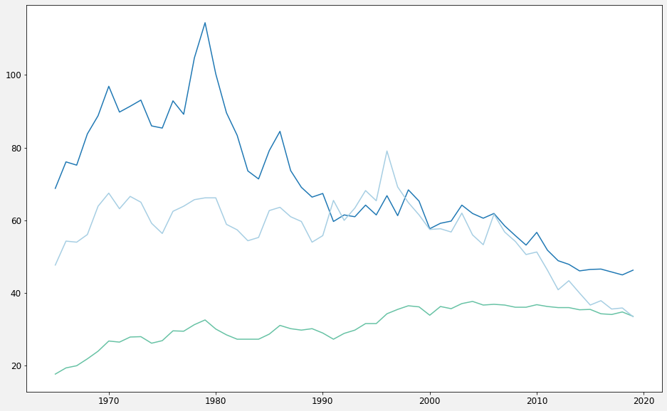

```python
fig, ax = plt.subplots()
ax.plot(utslipp["year"], utslipp["Norway"])
ax.plot(utslipp["year"], utslipp["Sweden"])
ax.plot(utslipp["year"], utslipp["Denmark"])
plt.show()
```

It would be good to get some labels on this chart - both for the individual series labels, and for the y-axis

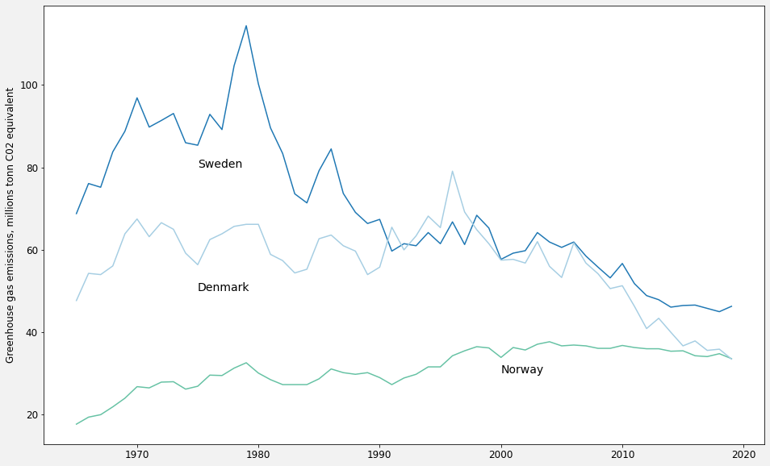

```python
fig, ax = plt.subplots()
ax.plot(utslipp["year"], utslipp["Norway"])
ax.annotate("Norway", xy=(2000, 30))
ax.plot(utslipp["year"], utslipp["Sweden"])
ax.annotate("Sweden", xy=(1975, 80))
ax.plot(utslipp["year"], utslipp["Denmark"])
ax.annotate("Denmark", xy=(1975, 50))
#ax.plot(utslipp["year"], utslipp["European Union"])
#ax.annotate("Air and sea traffic, fishing", xy=(2010, 6000))
ax.set_ylabel("Greenhouse gas emissions, millions tonn C02 equivalent")
plt.show()
```

This is a fairly basic time-series chart, but it actually gives us a lot of information. We will talk more about visualisation later, but an important principle is that an important point of visualisation is to make comparisons. Here we get a very stark comparison between emissions in Norway, on the one hand, and Denmark and Sweden on the other in this 50 year period.

- Why do you think they have such diverging emissions trends?
- Why did Norway have such low emissions compared to Denmark and Sweden in the 1960s?
- What has Denmark done since 2000 that has led to such a large fall in emissions?
- Are there ways that this visualisation is *lying* or perhaps misrepresenting reality? Are there transformations we could do to make the visualisation more honest?